# R Notebook

```r
library(GGally)
```

```r
orange_juice <- read_csv(here::here("data/orange_juice.csv")) %>%
  janitor::clean_names()
glimpse(orange_juice)
```

```
Rows: 1,070
Columns: 18
$ purchase        <chr> "CH", "CH", "CH", "MM", "CH", "CH", "CH", "CH", "CH", "CH", "CH", "CH", "CH", "CH", "CH"…
$ weekof_purchase <dbl> 237, 239, 245, 227, 228, 230, 232, 234, 235, 238, 240, 263, 276, 268, 278, 278, 240, 268…
$ store_id        <dbl> 1, 1, 1, 1, 7, 7, 7, 7, 7, 7, 7, 7, 7, 7, 7, 7, 1, 2, 2, 7, 7, 1, 7, 7, 7, 7, 7, 7, 7, 7…
$ price_ch        <dbl> 1.75, 1.75, 1.86, 1.69, 1.69, 1.69, 1.69, 1.75, 1.75, 1.75, 1.86, 1.86, 1.99, 1.86, 2.06…
$ price_mm        <dbl> 1.99, 1.99, 2.09, 1.69, 1.69, 1.99, 1.99, 1.99, 1.99, 1.99, 2.09, 2.13, 2.13, 2.13, 2.13…
$ disc_ch         <dbl> 0.00, 0.00, 0.17, 0.00, 0.00, 0.00, 0.00, 0.00, 0.00, 0.00, 0.00, 0.27, 0.00, 0.00, 0.00…
$ disc_mm         <dbl> 0.00, 0.30, 0.00, 0.00, 0.00, 0.00, 0.40, 0.40, 0.40, 0.40, 0.00, 0.00, 0.54, 0.00, 0.00…
$ special_ch      <dbl> 0, 0, 0, 0, 0, 0, 1, 1, 0, 0, 0, 0, 0, 0, 0, 0, 0, 0, 0, 0, 0, 0, 0, 1, 0, 1, 0, 0, 1, 0…
$ special_mm      <dbl> 0, 1, 0, 0, 0, 1, 1, 0, 0, 0, 0, 0, 1, 0, 0, 0, 1, 1, 0, 0, 0, 0, 0, 0, 0, 0, 0, 0, 0, 0…
$ loyal_ch        <dbl> 0.500000, 0.600000, 0.680000, 0.400000, 0.956535, 0.965228, 0.972182, 0.977746, 0.982197…
$ sale_price_mm   <dbl> 1.99, 1.69, 2.09, 1.69, 1.69, 1.99, 1.59, 1.59, 1.59, 1.59, 2.09, 2.13, 1.59, 2.13, 2.13…
$ sale_price_ch   <dbl> 1.75, 1.75, 1.69, 1.69, 1.69, 1.69, 1.69, 1.75, 1.75, 1.75, 1.86, 1.59, 1.99, 1.86, 2.06…
$ price_diff      <dbl> 0.24, -0.06, 0.40, 0.00, 0.00, 0.30, -0.10, -0.16, -0.16, -0.16, 0.23, 0.54, -0.40, 0.27…
$ store7          <chr> "No", "No", "No", "No", "Yes", "Yes", "Yes", "Yes", "Yes", "Yes", "Yes", "Yes", "Yes", "…
$ pct_disc_mm     <dbl> 0.000000, 0.150754, 0.000000, 0.000000, 0.000000, 0.000000, 0.201005, 0.201005, 0.201005…
$ pct_disc_ch     <dbl> 0.000000, 0.000000, 0.091398, 0.000000, 0.000000, 0.000000, 0.000000, 0.000000, 0.000000…
$ list_price_diff <dbl> 0.24, 0.24, 0.23, 0.00, 0.00, 0.30, 0.30, 0.24, 0.24, 0.24, 0.23, 0.27, 0.14, 0.27, 0.07…
$ store           <dbl> 1, 1, 1, 1, 0, 0, 0, 0, 0, 0, 0, 0, 0, 0, 0, 0, 1, 2, 2, 0, 0, 1, 0, 0, 0, 0, 0, 0, 0, 0…
```

```r
summary(orange_juice)
```

```
   purchase         weekof_purchase    store_id       price_ch        price_mm        disc_ch
 Length:1070        Min.   :227.0   Min.   :1.00   Min.   :1.690   Min.   :1.690   Min.   :0.00000
 Class :character   1st Qu.:240.0   1st Qu.:2.00   1st Qu.:1.790   1st Qu.:1.990   1st Qu.:0.00000
 Mode  :character   Median :257.0   Median :3.00   Median :1.860   Median :2.090   Median :0.00000
                    Mean   :254.4   Mean   :3.96   Mean   :1.867   Mean   :2.085   Mean   :0.05186
                    3rd Qu.:268.0   3rd Qu.:7.00   3rd Qu.:1.990   3rd Qu.:2.180   3rd Qu.:0.00000
                    Max.   :278.0   Max.   :7.00   Max.   :2.090   Max.   :2.290   Max.   :0.50000
    disc_mm         special_ch       special_mm        loyal_ch        sale_price_mm   sale_price_ch
 Min.   :0.0000   Min.   :0.0000   Min.   :0.0000   Min.   :0.000011   Min.   :1.190   Min.   :1.390
 1st Qu.:0.0000   1st Qu.:0.0000   1st Qu.:0.0000   1st Qu.:0.325257   1st Qu.:1.690   1st Qu.:1.750
 Median :0.0000   Median :0.0000   Median :0.0000   Median :0.600000   Median :2.090   Median :1.860
 Mean   :0.1234   Mean   :0.1477   Mean   :0.1617   Mean   :0.565782   Mean   :1.962   Mean   :1.816
 3rd Qu.:0.2300   3rd Qu.:0.0000   3rd Qu.:0.0000   3rd Qu.:0.850873   3rd Qu.:2.130   3rd Qu.:1.890
 Max.   :0.8000   Max.   :1.0000   Max.   :1.0000   Max.   :0.999947   Max.   :2.290   Max.   :2.090
   price_diff         store7           pct_disc_mm      pct_disc_ch      list_price_diff     store
 Min.   :-0.6700   Length:1070        Min.   :0.0000   Min.   :0.00000   Min.   :0.000   Min.   :0.000
 1st Qu.: 0.0000   Class :character   1st Qu.:0.0000   1st Qu.:0.00000   1st Qu.:0.140   1st Qu.:0.000
 Median : 0.2300   Mode  :character   Median :0.0000   Median :0.00000   Median :0.240   Median :2.000
 Mean   : 0.1465                      Mean   :0.0593   Mean   :0.02731   Mean   :0.218   Mean   :1.631
 3rd Qu.: 0.3200                      3rd Qu.:0.1127   3rd Qu.:0.00000   3rd Qu.:0.300   3rd Qu.:3.000
 Max.   : 0.6400                      Max.   :0.4020   Max.   :0.25269   Max.   :0.440   Max.   :4.000
```

```r
orange_juice
```

| purchase | weekof_purchase | store_id | price_ch | price_mm | disc_ch | disc_mm | special_ch | special_mm | loyal_ch | sale_price_mm | sale_price_ch | price_diff | store7 | pct_disc_mm | pct_disc_ch | list_price_diff | store |
| --- | --- | --- | --- | --- | --- | --- | --- | --- | --- | --- | --- | --- | --- | --- | --- | --- | --- |
| CH | 237 | 1 | 1.75 | 1.99 | 0.00 | 0.00 | 0 | 0 | 0.500000 | 1.99 | 1.75 | 0.24 | No | 0.000000 | 0.000000 | 0.24 | 1 |
| CH | 239 | 1 | 1.75 | 1.99 | 0.00 | 0.30 | 0 | 1 | 0.600000 | 1.69 | 1.75 | -0.06 | No | 0.150754 | 0.000000 | 0.24 | 1 |
| CH | 245 | 1 | 1.86 | 2.09 | 0.17 | 0.00 | 0 | 0 | 0.680000 | 2.09 | 1.69 | 0.40 | No | 0.000000 | 0.091398 | 0.23 | 1 |
| MM | 227 | 1 | 1.69 | 1.69 | 0.00 | 0.00 | 0 | 0 | 0.400000 | 1.69 | 1.69 | 0.00 | No | 0.000000 | 0.000000 | 0.00 | 1 |
| CH | 228 | 7 | 1.69 | 1.69 | 0.00 | 0.00 | 0 | 0 | 0.956535 | 1.69 | 1.69 | 0.00 | Yes | 0.000000 | 0.000000 | 0.00 | 0 |
| CH | 230 | 7 | 1.69 | 1.99 | 0.00 | 0.00 | 0 | 1 | 0.965228 | 1.99 | 1.69 | 0.30 | Yes | 0.000000 | 0.000000 | 0.30 | 0 |
| CH | 232 | 7 | 1.69 | 1.99 | 0.00 | 0.40 | 1 | 1 | 0.972182 | 1.59 | 1.69 | -0.10 | Yes | 0.201005 | 0.000000 | 0.30 | 0 |
| CH | 234 | 7 | 1.75 | 1.99 | 0.00 | 0.40 | 1 | 0 | 0.977746 | 1.59 | 1.75 | -0.16 | Yes | 0.201005 | 0.000000 | 0.24 | 0 |
| CH | 235 | 7 | 1.75 | 1.99 | 0.00 | 0.40 | 0 | 0 | 0.982197 | 1.59 | 1.75 | -0.16 | Yes | 0.201005 | 0.000000 | 0.24 | 0 |
| CH | 238 | 7 | 1.75 | 1.99 | 0.00 | 0.40 | 0 | 0 | 0.985757 | 1.59 | 1.75 | -0.16 | Yes | 0.201005 | 0.000000 | 0.24 | 0 |

[output cut: 990 more lines]

```r
# verify if store7 and store are redundant variables
orange_juice %>%
  filter(store_id != store & store_id != 7)
```

| purchase | weekof_purchase | store_id | price_ch | price_mm | disc_ch | disc_mm | special_ch | special_mm | loyal_ch | sale_price_mm | sale_price_ch | price_diff | store7 | pct_disc_mm | pct_disc_ch | list_price_diff | store |
| --- | --- | --- | --- | --- | --- | --- | --- | --- | --- | --- | --- | --- | --- | --- | --- | --- | --- |

```r
# price_diff = sale_price_mm - sale_price_ch --> redundant
# sale_price = price - disc --> redundant
# list_price_diff = price_mm - price_ch --> redundant

# drop redundant variables and mutate categorical variables into factors
oj <- orange_juice %>%
  select(-c(weekof_purchase, store7, store, price_diff, list_price_diff, disc_ch, disc_mm)) %>% # there is a store_id already
  rename(purchase_mm = purchase) %>%
  mutate(purchase_mm = as.factor(if_else(purchase_mm == "MM", TRUE, FALSE)),
         special_ch = as.factor(if_else(special_ch == 1, TRUE, FALSE)),
         special_mm = as.factor(if_else(special_mm == 1, TRUE, FALSE)),
         store_id = as.factor(store_id)
   )

oj
```

| purchase_mm | store_id | price_ch | price_mm | special_ch | special_mm | loyal_ch | sale_price_mm | sale_price_ch | pct_disc_mm | pct_disc_ch |
| --- | --- | --- | --- | --- | --- | --- | --- | --- | --- | --- |
| FALSE | 1 | 1.75 | 1.99 | FALSE | FALSE | 0.500000 | 1.99 | 1.75 | 0.000000 | 0.000000 |
| FALSE | 1 | 1.75 | 1.99 | FALSE | TRUE | 0.600000 | 1.69 | 1.75 | 0.150754 | 0.000000 |
| FALSE | 1 | 1.86 | 2.09 | FALSE | FALSE | 0.680000 | 2.09 | 1.69 | 0.000000 | 0.091398 |
| TRUE | 1 | 1.69 | 1.69 | FALSE | FALSE | 0.400000 | 1.69 | 1.69 | 0.000000 | 0.000000 |
| FALSE | 7 | 1.69 | 1.69 | FALSE | FALSE | 0.956535 | 1.69 | 1.69 | 0.000000 | 0.000000 |
| FALSE | 7 | 1.69 | 1.99 | FALSE | TRUE | 0.965228 | 1.99 | 1.69 | 0.000000 | 0.000000 |
| FALSE | 7 | 1.69 | 1.99 | TRUE | TRUE | 0.972182 | 1.59 | 1.69 | 0.201005 | 0.000000 |
| FALSE | 7 | 1.75 | 1.99 | TRUE | FALSE | 0.977746 | 1.59 | 1.75 | 0.201005 | 0.000000 |
| FALSE | 7 | 1.75 | 1.99 | FALSE | FALSE | 0.982197 | 1.59 | 1.75 | 0.201005 | 0.000000 |
| FALSE | 7 | 1.75 | 1.99 | FALSE | FALSE | 0.985757 | 1.59 | 1.75 | 0.201005 | 0.000000 |

[output cut: 990 more lines]

```r
alias(purchase_mm ~ ., data = oj)
```

```
Model :
purchase_mm ~ store_id + price_ch + price_mm + special_ch + special_mm +
    loyal_ch + sale_price_mm + sale_price_ch + pct_disc_mm +
    pct_disc_ch
```

### Automated Method

Run an exhaustive search over all `main effects only` logistic regression models using BIC as the quality metric

```r
glmulti_search_all_mains <- glmulti(
  purchase_mm ~ .,
  data = oj,
  level = 1,               # No interactions considered, main effects only
  method = "h",            # Exhaustive approach
  crit = "bic",            # BIC as criteria
  confsetsize = 10,        # Keep 10 best models
  plotty = F,
  report = T,              # No plots, but provide interim reports
  fitfunction = "glm",     # glm function
  family = binomial(link = "logit")) # binomial family for logistic regression

summary(glmulti_search_all_mains)
```

Best model returned : purchase_mm ~ 1 + loyal_ch + sale_price_mm + sale_price_ch

You would like to add on a single pair interaction considering only main effects in the model. Which single pair addition leads to lowest BIC?

```r
glmulti_search_previous_mains_one_pair <- glmulti(
  purchase_mm ~ 1 + loyal_ch + sale_price_mm + sale_price_ch,
  data = oj,
  level = 2,               # Interactions considered
  method = "h",            # Exhaustive approach
  crit = "bic",            # BIC as criteria
  confsetsize = 10,        # Keep 10 best models
  marginality = TRUE,      # consider pairs only if both main effects in model
  minsize = 6,             # minsize, maxsize and marginality here force
  maxsize = 6,             # inclusion of a single pair beyond the five main effects
  plotty = F,
  report = T,              # No plots, but provide interim reports
  fitfunction = "glm",     # glm function
  family = binomial(link = "logit")) # binomial family for logistic regression

summary(glmulti_search_previous_mains_one_pair)
```

[output not shown]

Alternatively: In cases where an exhaustive search isn’t possible because there are too many possible models to search through, you could try a search using a genetic algorithm. Here, run a genetic algorithm search over all main effects plus pair models, using lowest AIC as the quality criterion.

```r
# WARNING - it takes 5 minutes tu run
glmulti_ga_search_with_pairs_aic <- glmulti(
  purchase_mm ~ .,
  data = oj,
  level = 2,               # Interactions considered
  method = "g",            # Genetic algorithm approach
  crit = "aic",            # AIC as criteria
  confsetsize = 10,        # Keep 10 best models
  marginality = TRUE,      # consider pairs only if both main effects in model
  plotty = F,
  report = T,              # No plots, but provide interim reports
  fitfunction = "glm",     # glm function
  family = binomial(link = "logit")) # binomial family for logistic regression

summary(glmulti_ga_search_with_pairs_aic)
```

After 300 generations: Best model: purchase_mm~1+store_id+special_ch+special_mm+price_ch+price_mm+loyal_ch+sale_price_mm+sale_price_ch+pct_disc_mm+special_mm:special_ch+price_mm:price_ch+loyal_ch:price_mm+sale_price_mm:price_ch+sale_price_mm:loyal_ch+sale_price_ch:price_mm+sale_price_ch:loyal_ch+sale_price_ch:sale_price_mm+pct_disc_mm:price_ch+pct_disc_mm:price_mm+pct_disc_mm:loyal_ch+pct_disc_mm:sale_price_ch+store_id:sale_price_mm+store_id:pct_disc_mm+special_ch:sale_price_ch

### Manual method

```r
oj_num <- oj %>%
  select(purchase_mm, price_ch, price_mm, loyal_ch, sale_price_mm, sale_price_ch, pct_disc_mm, pct_disc_ch)

oj_fact <- oj %>%
  select(purchase_mm, store_id, special_ch, special_mm)
```

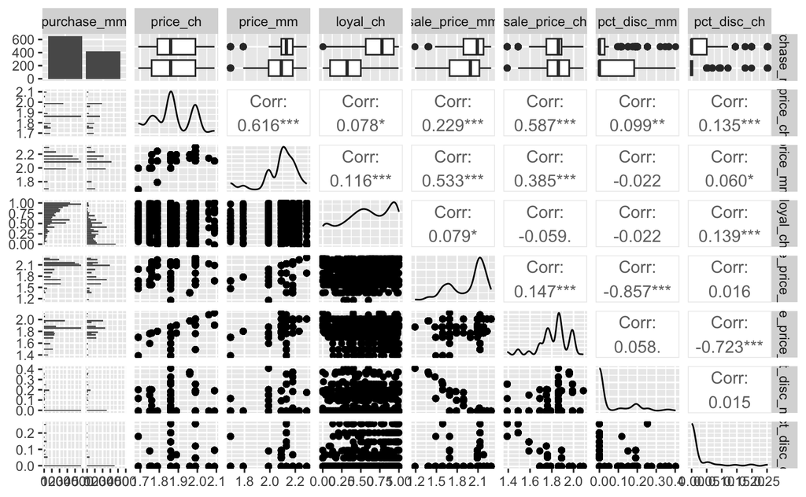

```r
ggpairs(oj_num %>%
          select(purchase_mm, everything()))
```

Percentage discounts and Customer brand loyalty for CH seem to be relevant.

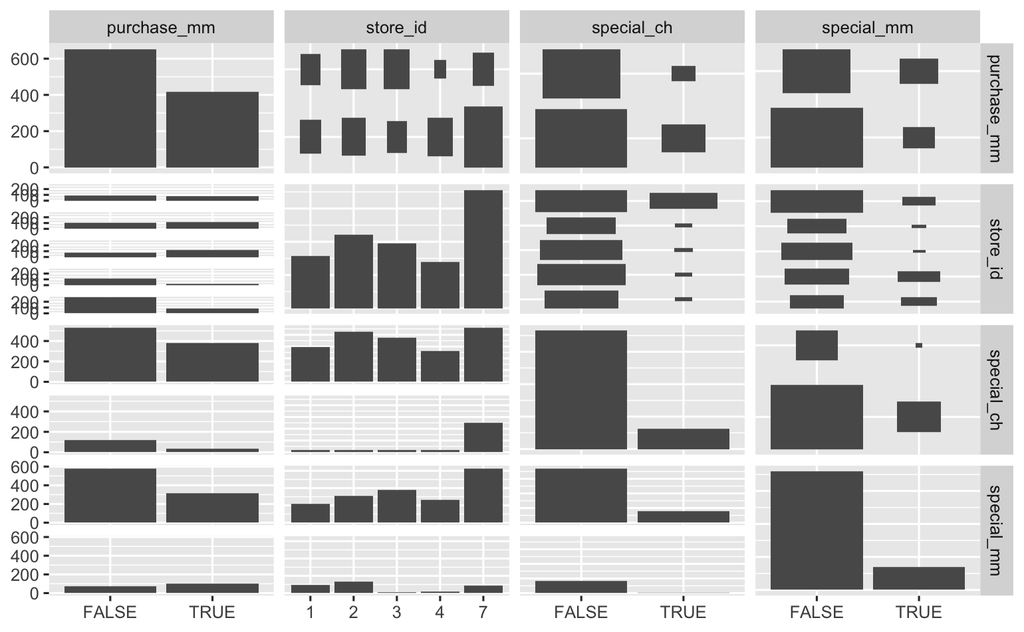

```r
ggpairs(oj_fact %>%
          select(purchase_mm, everything()))
```

Special on mm/ch seem relevant